# Assignment #2 - Classification

**Due: Oct 15 (Tuesday) 11:00 pm**

Siddhi Degaonkar

# I. Introduction

**Purpose and Objective**: Objective if Assignment 2 is to implement the various Classification models like Pocket , LDA , QDA, Logistic Regression on Bank marketing dataset and to compare and analyze the results given by these models by using various model metrics like Precision , Recall, PR Curve, Recall, Accuracies.

**Scope of Assignment** Assignment # 2 consist of introduction to four Classification models. The assignment consist of :

1. Introduction to data and data source
2. Read and analyze the raw data from csv file.
3. Data Visualization using various techniques.
4. Preliminary Observations on data.
5. Extracting observations from visualized data and choosing a right set of columns.
6. Data Preprocessing like normalization and one hot encoding is done for categorical attributes.
7. Building classification models Pocket, LDA, QDA, Logistics Regression.
8. Train and use model.
9. Plot the graph of Test data Vs Predicted Data.
10. Using various model metrics like Precision , Recall, PR Curve, Recall, Accuracies.
11. Analysis / comparison of algorithms.

**Conclusion** is derived and **references** are presented.

# II. Data

- The data is related with direct marketing campaigns of a Portuguese banking institution. The marketing campaigns were based on phone calls. Often, more than one contact to the same client was required, in order to access if the product (bank term deposit) would be ('yes') or not ('no') subscribed.
- Bank-additional-full.csv with all examples (41188) and 20 inputs, ordered by date (from May 2008 to November 2010), very close to the data analyzed in [Moro et al., 2014] **Attribute Information:** **Bank client data:**
1. Age (numeric)
2. Job : type of job (categorical: 'admin.', 'blue-collar', 'entrepreneur', 'housemaid', 'management', 'retired', 'self-employed', 'services', 'student', 'technician', 'unemployed', 'unknown')
3. Marital : marital status (categorical: 'divorced', 'married', 'single', 'unknown' ; note: 'divorced' means divorced or widowed)
4. Education (categorical: 'basic.4y', 'basic.6y', 'basic.9y', 'high.school', 'illiterate', 'professional.course', 'university.degree', 'unknown')
5. Default: has credit in default? (categorical: 'no', 'yes', 'unknown')
6. Housing: has housing loan? (categorical: 'no', 'yes', 'unknown')
7. Loan: has personal loan? (categorical: 'no', 'yes', 'unknown')
8. Related with the last contact of the current campaign:
9. Contact: contact communication type (categorical: 'cellular','telephone')
10. Month: last contact month of year (categorical: 'jan', 'feb', 'mar', ..., 'nov', 'dec')
11. Day_of_week: last contact day of the week (categorical: 'mon','tue','wed','thu','fri')
12. Duration: last contact duration, in seconds (numeric). Important note: this attribute highly affects the output target (e.g., if duration=0 then y='no'). Yet, the duration is not known before a call is performed. Also, after the end of the call y is obviously known. Thus, this input should only be included for benchmark purposes and should be discarded if the intention is to have a realistic predictive model. **Other attributes:**
13. Campaign: number of contacts performed during this campaign and for this client (numeric, includes last contact)
14. Pdays: number of days that passed by after the client was last contacted from a previous campaign (numeric; 999 means client was not previously contacted)
15. Previous: number of contacts performed before this campaign and for this client (numeric)
16. Poutcome: outcome of the previous marketing campaign (categorical: 'failure','nonexistent','success') **Social and economic context attributes**
17. Emp.var.rate: employment variation rate - quarterly indicator (numeric)
18. Cons.price.idx: consumer price index - monthly indicator (numeric)
19. Cons.conf.idx: consumer confidence index - monthly indicator (numeric)
20. Euribor3m: euribor 3 month rate - daily indicator (numeric)
21. Nr.employed: number of employees - quarterly indicator (numeric) **Output variable (desired target):**
22. y - has the client subscribed a term deposit? (binary: 'yes', 'no')

```python
import numpy as np
import pandas as pd
import matplotlib.pyplot as plt
import seaborn as sns

df = pd.read_csv('bank-additional-full.csv',sep=";")
df.head()
```

|  | age | job | marital | education | default | housing | loan | contact | month | day_of_week | ... | campaign | pdays | previous | poutcome | emp.var.rate | cons.price.idx | cons.conf.idx | euribor3m | nr.employed | y |
| --- | --- | --- | --- | --- | --- | --- | --- | --- | --- | --- | --- | --- | --- | --- | --- | --- | --- | --- | --- | --- | --- |
| 0 | 56 | housemaid | married | basic.4y | no | no | no | telephone | may | mon | ... | 1 | 999 | 0 | nonexistent | 1.1 | 93.994 | -36.4 | 4.857 | 5191.0 | no |
| 1 | 57 | services | married | high.school | unknown | no | no | telephone | may | mon | ... | 1 | 999 | 0 | nonexistent | 1.1 | 93.994 | -36.4 | 4.857 | 5191.0 | no |
| 2 | 37 | services | married | high.school | no | yes | no | telephone | may | mon | ... | 1 | 999 | 0 | nonexistent | 1.1 | 93.994 | -36.4 | 4.857 | 5191.0 | no |
| 3 | 40 | admin. | married | basic.6y | no | no | no | telephone | may | mon | ... | 1 | 999 | 0 | nonexistent | 1.1 | 93.994 | -36.4 | 4.857 | 5191.0 | no |
| 4 | 56 | services | married | high.school | no | no | yes | telephone | may | mon | ... | 1 | 999 | 0 | nonexistent | 1.1 | 93.994 | -36.4 | 4.857 | 5191.0 | no |

5 rows × 21 columns

```python
print(df.shape)
```

```
(41188, 21)
```

```python
df.info()
```

```
<class 'pandas.core.frame.DataFrame'>
RangeIndex: 41188 entries, 0 to 41187
Data columns (total 21 columns):
age               41188 non-null int64
job               41188 non-null object
marital           41188 non-null object
education         41188 non-null object
default           41188 non-null object
housing           41188 non-null object
loan              41188 non-null object
contact           41188 non-null object
month             41188 non-null object
day_of_week       41188 non-null object
duration          41188 non-null int64
campaign          41188 non-null int64
pdays             41188 non-null int64
previous          41188 non-null int64
poutcome          41188 non-null object
emp.var.rate      41188 non-null float64
cons.price.idx    41188 non-null float64
cons.conf.idx     41188 non-null float64
euribor3m         41188 non-null float64
nr.employed       41188 non-null float64
y                 41188 non-null object
dtypes: float64(5), int64(5), object(11)
memory usage: 6.6+ MB
```

### PLOTS For Understanding

```python
#find missing values for each column
missing_values = df.isnull().mean()
missing_values.sum()
```

```
0.0
```

```python
df.describe()
```

|  | age | duration | campaign | pdays | previous | emp.var.rate | cons.price.idx | cons.conf.idx | euribor3m | nr.employed |
| --- | --- | --- | --- | --- | --- | --- | --- | --- | --- | --- |
| count | 41188.00000 | 41188.000000 | 41188.000000 | 41188.000000 | 41188.000000 | 41188.000000 | 41188.000000 | 41188.000000 | 41188.000000 | 41188.000000 |
| mean | 40.02406 | 258.285010 | 2.567593 | 962.475454 | 0.172963 | 0.081886 | 93.575664 | -40.502600 | 3.621291 | 5167.035911 |
| std | 10.42125 | 259.279249 | 2.770014 | 186.910907 | 0.494901 | 1.570960 | 0.578840 | 4.628198 | 1.734447 | 72.251528 |
| min | 17.00000 | 0.000000 | 1.000000 | 0.000000 | 0.000000 | -3.400000 | 92.201000 | -50.800000 | 0.634000 | 4963.600000 |
| 25% | 32.00000 | 102.000000 | 1.000000 | 999.000000 | 0.000000 | -1.800000 | 93.075000 | -42.700000 | 1.344000 | 5099.100000 |
| 50% | 38.00000 | 180.000000 | 2.000000 | 999.000000 | 0.000000 | 1.100000 | 93.749000 | -41.800000 | 4.857000 | 5191.000000 |
| 75% | 47.00000 | 319.000000 | 3.000000 | 999.000000 | 0.000000 | 1.400000 | 93.994000 | -36.400000 | 4.961000 | 5228.100000 |
| max | 98.00000 | 4918.000000 | 56.000000 | 999.000000 | 7.000000 | 1.400000 | 94.767000 | -26.900000 | 5.045000 | 5228.100000 |

```python
#sns.pairplot(df)
```

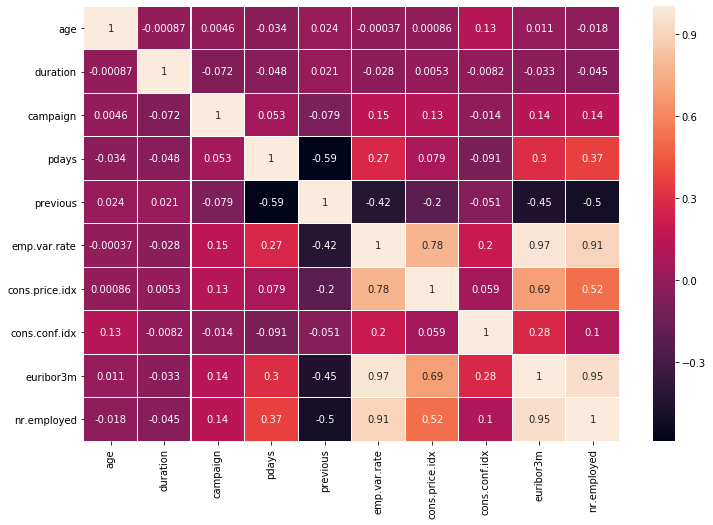

```python
#from sklearn.preprocessing import StandardScaler, OneHotEncoder, LabelEncoder
fig = plt.figure(figsize=(12,8))
#df['y'] = LabelEncoder().fit_transform(df['y'])
sns.heatmap(df.corr(), annot=True, linewidths=.1)
plt.show()
```

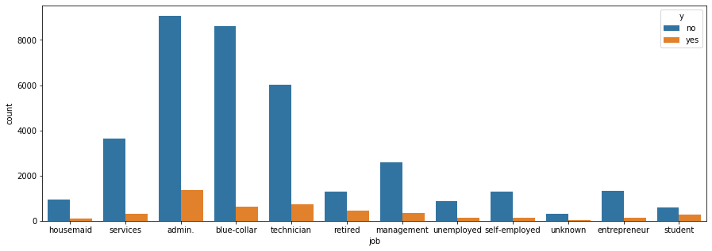

```python
# Classification according to Jobs
plt.figure(figsize=[15,5])
sns.countplot(x='job', hue='y', data=df)
```

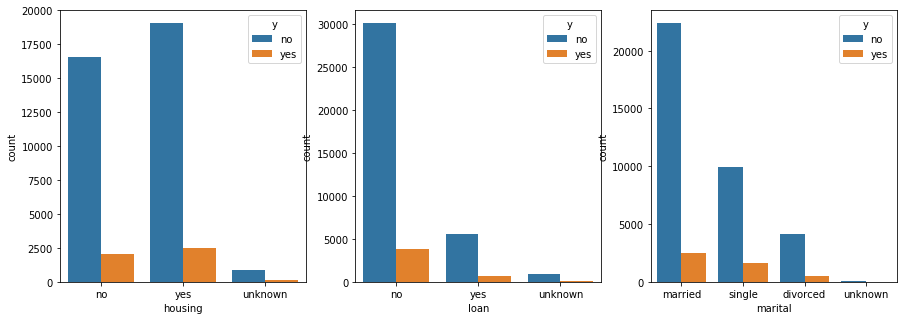

```python
# Classification based on housing and loan , marital status
plt.figure(figsize=[15,5])
plt.subplot(1,3,1)
sns.countplot(x='housing', hue='y', data=df)
plt.subplot(1,3,2)
sns.countplot(x='loan', hue='y', data=df)
plt.subplot(1,3,3)
sns.countplot(x='marital', hue='y', data=df)
plt.show()
```

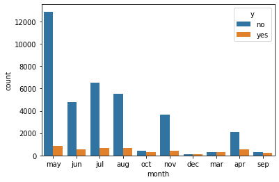

```python
# Classification based on Month
sns.countplot(x='month', hue='y', data=df)
```

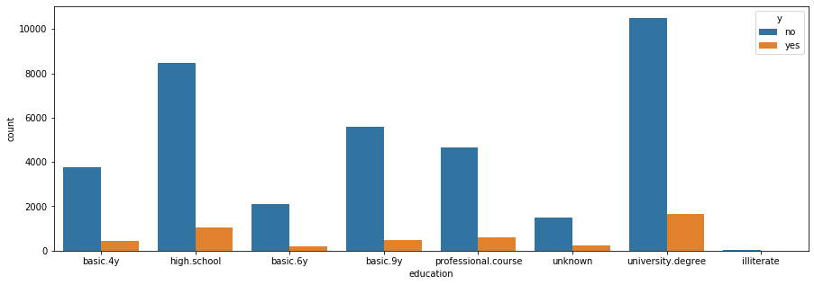

```python
# Classification based on Education
plt.figure(figsize=[15,5])
sns.countplot(x='education', hue='y', data=df)
```

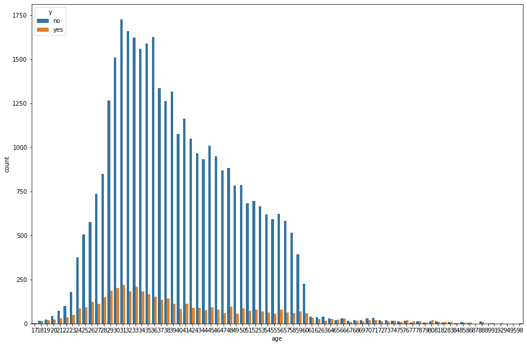

```python
plt.figure(figsize=[15,10])
sns.countplot(x='age', hue='y', data=df)
```

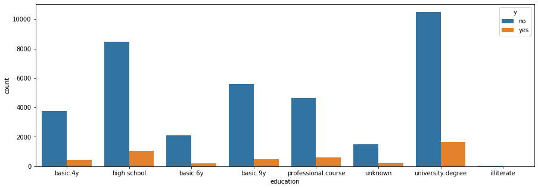

```python
# Classification based on Education
plt.figure(figsize=[15,5])
sns.countplot(x='education', hue='y', data=df)
```

### The education classes basic.4y, basic.6y, basic.9y can be merged togethere into basic class

```python
df['education'].unique()
```

```
array(['basic.4y', 'high.school', 'basic.6y', 'basic.9y',
       'professional.course', 'unknown', 'university.degree',
       'illiterate'], dtype=object)
```

```python
df['education']=np.where(df['education'] =='basic.9y', 'basic', df['education'])
df['education']=np.where(df['education'] =='basic.6y', 'basic', df['education'])
df['education']=np.where(df['education'] =='basic.4y', 'basic', df['education'])
```

```python
df['education'].unique()
```

```
array(['basic', 'high.school', 'professional.course', 'unknown',
       'university.degree', 'illiterate'], dtype=object)
```

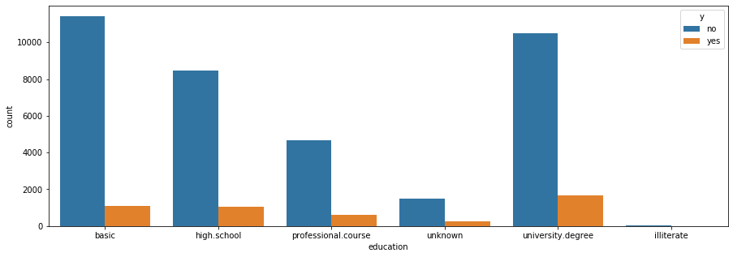

```python
# Classification based on Education
plt.figure(figsize=[15,5])
sns.countplot(x='education', hue='y', data=df)
```

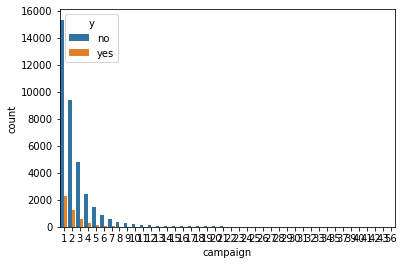

```python
# Based on days of Campaign: number of contacts performed during this campaign.
sns.countplot(x='campaign', hue='y', data=df)
```

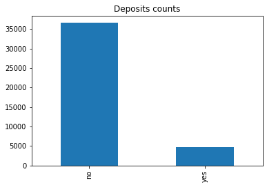

```python
value_count = df['y'].value_counts()
value_count.plot.bar(title = 'Deposits counts')
```

**PRELIMINARY OBSERVATION FOR CLASSIFICATION DATA**

```python
df.columns
df.shape
```

```
(41188, 21)
```

```python
df_bank = df
df_bank.head(2)
```

|  | age | job | marital | education | default | housing | loan | contact | month | day_of_week | ... | campaign | pdays | previous | poutcome | emp.var.rate | cons.price.idx | cons.conf.idx | euribor3m | nr.employed | y |
| --- | --- | --- | --- | --- | --- | --- | --- | --- | --- | --- | --- | --- | --- | --- | --- | --- | --- | --- | --- | --- | --- |
| 0 | 56 | housemaid | married | basic | no | no | no | telephone | may | mon | ... | 1 | 999 | 0 | nonexistent | 1.1 | 93.994 | -36.4 | 4.857 | 5191.0 | no |
| 1 | 57 | services | married | high.school | unknown | no | no | telephone | may | mon | ... | 1 | 999 | 0 | nonexistent | 1.1 | 93.994 | -36.4 | 4.857 | 5191.0 | no |

2 rows × 21 columns

```python
#Drop the unnecessary columns
pd.isnull(df_bank).any()
```

```
age               False
job               False
marital           False
education         False
default           False
housing           False
loan              False
contact           False
month             False
day_of_week       False
duration          False
campaign          False
pdays             False
previous          False
poutcome          False
emp.var.rate      False
cons.price.idx    False
cons.conf.idx     False
euribor3m         False
nr.employed       False
y                 False
dtype: bool
```

```python
df_bank.info()
```

```
<class 'pandas.core.frame.DataFrame'>
RangeIndex: 41188 entries, 0 to 41187
Data columns (total 21 columns):
age               41188 non-null int64
job               41188 non-null object
marital           41188 non-null object
education         41188 non-null object
default           41188 non-null object
housing           41188 non-null object
loan              41188 non-null object
contact           41188 non-null object
month             41188 non-null object
day_of_week       41188 non-null object
duration          41188 non-null int64
campaign          41188 non-null int64
pdays             41188 non-null int64
previous          41188 non-null int64
poutcome          41188 non-null object
emp.var.rate      41188 non-null float64
cons.price.idx    41188 non-null float64
cons.conf.idx     41188 non-null float64
euribor3m         41188 non-null float64
nr.employed       41188 non-null float64
y                 41188 non-null object
dtypes: float64(5), int64(5), object(11)
memory usage: 6.6+ MB
```

```python
#df1 = df_bank.drop(columns=['default','contact','poutcome','previous'])
```

```python
df_bank.shape
```

```
(41188, 21)
```

```python
"""from sklearn.preprocessing import StandardScaler, OneHotEncoder, LabelEncoder
df1['housing'] = LabelEncoder().fit_transform(df1['housing'])
df1['loan'] = LabelEncoder().fit_transform(df1['loan'])
#df1['y'] = LabelEncoder().fit_transform(df1['y'])
df1['job'] = LabelEncoder().fit_transform(df1['job'])
df1['marital'] = LabelEncoder().fit_transform(df1['marital'])
df1['education'] = LabelEncoder().fit_transform(df1['education'])
df1['month'] = LabelEncoder().fit_transform(df1['month'])
df1['day_of_week'] = LabelEncoder().fit_transform(df1['day_of_week'])
df1.head(15)"""
```

[output not shown]

```python
df_bank["housing"].value_counts()
```

```
yes        21576
no         18622
unknown      990
Name: housing, dtype: int64
```

```python
df_bank["loan"].value_counts()
```

```
no         33950
yes         6248
unknown      990
Name: loan, dtype: int64
```

```python
df_bank["y"].value_counts()
```

```
no     36548
yes     4640
Name: y, dtype: int64
```

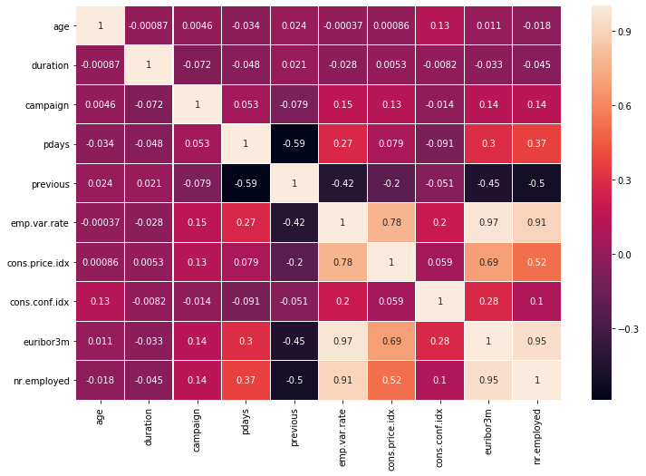

```python
fig = plt.figure(figsize=(12,8))
sns.heatmap(df_bank.corr(), annot=True, linewidths=.1)
plt.show()
```

```
['no', 'yes']
[36548, 4640]
```

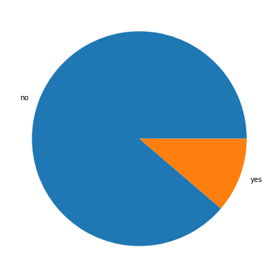

```python
import seaborn as sns
import matplotlib.pyplot as plt
groupName = []
count = []
for group_name, subset in df_bank.groupby('y'):
    groupName.append(group_name)
    count.append(len(subset))
print(groupName)
print(count)
plt.figure(figsize = (7, 7))
plt.pie(count, labels = groupName)
plt.show()
```

```python
df1 = df_bank
df1 = df1.rename(columns={'y': 'deposit'})
df1['deposit'].unique()
```

```
array(['no', 'yes'], dtype=object)
```

- For the Pocket algorithm "y" = deposit term needs to be encoded in the range of 1, -1

```python
#from sklearn.preprocessing import StandardScaler, OneHotEncoder, LabelEncoder
#df['y'] = LabelEncoder().fit_transform(df['y'])
```

```python
df1['deposit'] = df1['deposit'].apply(lambda x: 1 if x =='yes' else -1)
```

```python
df1['deposit'].unique()
```

```
array([-1,  1])
```

```python
df1.shape
```

```
(41188, 21)
```

#### Applying One hot Encoding on the dataset for the categorical columns:

```python
from sklearn.preprocessing import StandardScaler, OneHotEncoder, LabelEncoder
#converting each categoraicals coloumns to numerical values
cols =['job', 'marital', 'education', 'default', 'housing', 'loan',
       'contact', 'month', 'day_of_week', 'poutcome']
cols = df1[cols]
data_dummies = pd.get_dummies(cols)
#Concantenate the one hot encoded and original dataframe
final = pd.concat([data_dummies, df1], axis=1)
final.head()
final.columns
```

```
Index(['job_admin.', 'job_blue-collar', 'job_entrepreneur', 'job_housemaid',
       'job_management', 'job_retired', 'job_self-employed', 'job_services',
       'job_student', 'job_technician', 'job_unemployed', 'job_unknown',
       'marital_divorced', 'marital_married', 'marital_single',
       'marital_unknown', 'education_basic', 'education_high.school',
       'education_illiterate', 'education_professional.course',
       'education_university.degree', 'education_unknown', 'default_no',
       'default_unknown', 'default_yes', 'housing_no', 'housing_unknown',
       'housing_yes', 'loan_no', 'loan_unknown', 'loan_yes',
       'contact_cellular', 'contact_telephone', 'month_apr', 'month_aug',
       'month_dec', 'month_jul', 'month_jun', 'month_mar', 'month_may',
       'month_nov', 'month_oct', 'month_sep', 'day_of_week_fri',
       'day_of_week_mon', 'day_of_week_thu', 'day_of_week_tue',
       'day_of_week_wed', 'poutcome_failure', 'poutcome_nonexistent',
       'poutcome_success', 'age', 'job', 'marital', 'education', 'default',
       'housing', 'loan', 'contact', 'month', 'day_of_week', 'duration',
       'campaign', 'pdays', 'previous', 'poutcome', 'emp.var.rate',
       'cons.price.idx', 'cons.conf.idx', 'euribor3m', 'nr.employed',
       'deposit'],
      dtype='object')
```

```python
#Drop the extra columns from dataset
final_df=final.drop(['job', 'marital', 'education', 'default', 'housing', 'loan',
       'contact', 'month', 'day_of_week', 'poutcome'],axis=1)
final_df.shape
```

```
(41188, 62)
```

```python
#final_df.columns
```

```python
#Selecting colums
```

```python
cols=["euribor3m","job_blue-collar", "job_retired", "job_services", "job_student", "default_no",
      "month_aug", "month_dec", "month_jul", "month_nov", "month_oct", "month_sep", "day_of_week_fri", "day_of_week_wed",
      "poutcome_failure", "poutcome_nonexistent", "poutcome_success","deposit"]
df2=final_df[cols]
df2.shape
```

```
(41188, 18)
```

# Summary of Classification Models

### Pocket Algorithm

- The pocket algorithm with ratchet (Gallant, 1990) solves the stability problem of perceptron learning by keeping the best solution seen so far "in its pocket". The pocket algorithm then returns the solution in the pocket, rather than the last solution. It can be used also for non-separable data sets, where the aim is to find a perceptron with a small number of mis-classifications. However, these solutions appear purely stochastically and hence the pocket algorithm neither approaches them gradually in the course of learning, nor are they guaranteed to show up within a given number of learning steps.
- To overcome the unstability of the perceptron algorithm, the pocket algorithm keeps the best solution so far in its pocket. Thus, w_pocket will contain the best solution so far.
- The pocket algorithm is considered able to provide for any classification problem the weight vector which satisfies the maximum number of input-output relations contained in the training set. A proper convergence theorem ensures the achievement of an optimal configuration with probability one when the number of iterations grows indefinitely. In the present paper a new formulation of this theorem is given; a rigorous proof corrects some formal and substantial errors which invalidate previous theoretical results. In particular it is shown that the optimality of the asymptotical solution is ensured only if the number of permanences for the pocket vector lies in a proper interval of the real axis which bounds depend on the number of iterations

### Quadratic Discriminant Analysis

$$ P(T = +1 \mid x) > P(T = -1 \mid x). $$

The inequality will be the opposite in case of the negative samples.

To build our model to meet this expectation, we can play with the algebra a little bit.

$$ \begin{align*} P(T = +1 \mid x) &> P(T = -1 \mid x) \\ \\ \frac{P(x \mid T = +1) P(T = +1)} { P(x) } &> \frac{P(x \mid T = -1) P(T = -1)} { P(x) } \\ \\ P(x \mid T = +1) P(T = +1) &> P(x \mid T = -1) P(T = -1) \\ \\ \Big( (2\pi)^{\frac{d}{2}} \vert \boldsymbol\Sigma_+ \vert^{\frac{1}{2}} \Big)^{-1} e^{ -\frac{1}{2} (x - \boldsymbol\mu_+)^\top \boldsymbol\Sigma_+^{-1} (x - \boldsymbol\mu_+)} P(T = +1) &> \Big( (2\pi)^{\frac{d}{2}} \vert \boldsymbol\Sigma_- \vert^{\frac{1}{2}} \Big)^{-1} e^{ -\frac{1}{2} (x - \boldsymbol\mu_-)^\top \boldsymbol\Sigma_-^{-1} (x - \boldsymbol\mu_-)} P(T = -1) \\ \\ \Big( \vert \boldsymbol\Sigma_+ \vert^{\frac{1}{2}} \Big)^{-1} e^{ -\frac{1}{2} (x - \boldsymbol\mu_+)^\top \boldsymbol\Sigma_+^{-1} (x - \boldsymbol\mu_+)} P(T = +1) &> \Big( \vert \boldsymbol\Sigma_- \vert^{\frac{1}{2}} \Big)^{-1} e^{ -\frac{1}{2} (x - \boldsymbol\mu_-)^\top \boldsymbol\Sigma_-^{-1} (x- \boldsymbol\mu_-)} P(T = -1) \end{align*} $$

Logarithm can remove exponent and multiplication for easier computation:

$$ -\frac{1}{2} \ln \vert \boldsymbol\Sigma_+ \vert - \frac{1}{2} (x - \boldsymbol\mu_+)^\top \boldsymbol\Sigma_+^{-1} (x - \boldsymbol\mu_+) + \ln P(T = +1) > -\frac{1}{2} \ln \vert \boldsymbol\Sigma_- \vert - \frac{1}{2} (x - \boldsymbol\mu_-)^\top \boldsymbol\Sigma_-^{-1} (x- \boldsymbol\mu_-) + \ln P(T = -1) $$

From the observation that both terms have the same cosmetics, we can define the discriminant function $\delta_k(x)$ as

$$ \delta_k(x) = -\frac{1}{2} \ln \vert \boldsymbol\Sigma_k \vert - \frac{1}{2} (x - \boldsymbol\mu_k)^\top \boldsymbol\Sigma_k^{-1} (x - \boldsymbol\mu_k) + \ln P(T = k). $$

Now, for a new sample $\tilde{x}$, we can predict the label with

$$ y = \arg\max_k \delta_k(\tilde{x}). $$

The decision boundary is placed where the discriminant functions meet such as $\delta_1 == \delta_2$.

Since the $\delta_k$ function is quadratic in $x$, the decision boundary is quadratic. We call this approach as **Quadratic Discriminant Analysis (QDA)**.

## Linear Discriminant Analysis

Maintaining the covariance matrix is not cheap. Considering the input dimension $d$, the symmetric covariance metric contains $\frac{d (d+1)}{2}$.

Also, the data is under sampled, the resulting class boundary has high chance of overfitting.

Simply using the same covariance for all the classes, we can reach the **linear discriminant analysis** model, which can overcome the stated problems above.

Unifying the covariance matrix, we can remove the quadratic term in our disciriminant function:

$$ \delta_k(x) = x^\top \boldsymbol\Sigma^{-1} \boldsymbol\mu_k -\frac{1}{2} \boldsymbol\mu_k^\top \boldsymbol\Sigma^{-1}\boldsymbol\mu_k + \ln P(T = k). $$

In many cases, for simple computation, the covariance matrix $\boldsymbol\Sigma$ is chosen as an average of all the covariance matrices for all classes,

$$ \boldsymbol\Sigma = \sum_k^K \frac{N_k}{N} \boldsymbol\Sigma_k. $$

## Logistic Regression

Logistic regression is named for the function used at the core of the method, the logistic function.

The logistic function, also called the sigmoid function was developed by statisticians to describe properties of population growth in ecology, rising quickly and maxing out at the carrying capacity of the environment. It’s an S-shaped curve that can take any real-valued number and map it into a value between 0 and 1, but never exactly at those limits.

1 / (1 + e^-value)

Now, we consider a linear regression model that directly predicts $P(T=k \mid x)$, not the class label $k$. We call this approach as **Logistic Regression**.

Again, let us use the same linear model for regression:

$$ \kappa = f(x ; w) = X w. $$

Thus,

$$ P(T=k \mid x) = h(X w) = h(\kappa) = w. $$

### Target

To generate multiple probability outputs for each class, we consider the indicator output targets.

$$ T = \begin{bmatrix} t_{1,1} & t_{1,2} & \cdots & t_{1, K} \\ t_{2,1} & t_{2,2} & \cdots & t_{2, K} \\ \vdots & & & \vdots \\ t_{N,1} & t_{N,2} & \cdots & t_{N, K} \\ \end{bmatrix} $$

where $t_{n,k}$ is 0 or 1 with only one 1 per each row.

Note: Here the weight $w$ is not a vector any more. It is matrix with $D+1 \times K$ dimensions.

## Softmax Transformation

Before computing the derivative, let us select the function $h(\cdot)$.

Since $P(T=k \mid x)$ is probability function, it satisfies

- the outputs are non-negative,
- the integral of the probability is one.

To ensure this,

$$ P(T=k \mid x) = \frac{\kappa_k}{\sum_{c=1}^K \kappa_c} $$

Since we are working with the logarithm, an exponent is a good idea.

$$ g_k(x) = P(T=k \mid x) = \frac{e^{\kappa_k}}{\sum_{c=1}^K e^{\kappa_c}} $$

This function is called as **softmax function**. This generalizes the logistic sigmoid fuunction and the derivatives are given by itself

$$ \frac{\partial g_k}{\partial y_j} = g_k (I_{kj} - g_j). $$

# Super class Classifier

```python
import numpy as np
from abc import ABC, abstractmethod

# Super class for machine learning models

class BaseModel(ABC):
    """ Super class for ITCS Machine Learning Class"""

    @abstractmethod
    def train(self, X, T):
        pass

    @abstractmethod
    def use(self, X):
        pass



class Classifier(BaseModel):
    """
        Abstract class for classification

        Attributes
        ==========
        meanX       ndarray
                    mean of inputs (from standardization)
        stdX        ndarray
                    standard deviation of inputs (standardization)
    """

    def __init__(self, ):
        self.meanX = None
        self.stdX = None

    def normalize(self, X):
        """ standardize the input X """

        if not isinstance(X, np.ndarray):
            X = np.asanyarray(X)

        self.meanX = np.mean(X, 0)
        self.stdX = np.std(X, 0)

        # TODO: Finish this normalization
        Xs = X-self.meanX/self.stdX
        return Xs

    def _check_matrix(self, mat, name):
        if len(mat.shape) != 2:
            raise ValueError(''.join(["Wrong matrix ", name]))

    # add a basis
    def add_ones(self, X):
        """
            add a column basis to X input matrix
        """
        self._check_matrix(X, 'X')
        return np.hstack((np.ones((X.shape[0], 1)), X))

    ####################################################
    #### abstract funcitons ############################
    @abstractmethod
    def train(self, X, T):
        pass

    @abstractmethod
    def use(self, X):
        pass
```

#### Explanation to code:

The base is Classifier which will be inherited by the other child classes. It consists of two abstract methods train and use which will be implemented in the child classes LDA, QDA, PocketAlgorithm and Logistic. Normalize method is used to normalize the normalize the data. check_matrix() is used to check whether shape of matrix is 2D. add_ones is used to add column bias.

### Pocket

```python
from copy import deepcopy as copy
class PocketAlgorithm(Classifier):

    def __init__(self, alpha, interations):
        Classifier.__init__(self)
        self.iterations = interations
        self.alpha=alpha

    # return 1 if w is better -1 if wp is better
    def compare(self, X, T, w, wp):
        y = np.sign(X @ w)
        yp = np.sign(X @ wp)
        return 1 if np.sum(y == T) >= np.sum(yp == T) else -1


    def train(self, X, T):
        self.w = np.zeros(X.shape[1])
        self.w_pocket = copy(self.w)
        N=X.shape[0]
        for i in range(self.iterations):
            print("running",i)
            converged = True
            for k in np.random.permutation(N): #range(N):
                y = self.w @ X[k]
                if np.sign(y) != np.sign(T[k]):
                    self.w += self.alpha * T[k] * X[k]
                    converged = False
            ##### additional for pocket algorithm
                if self.compare(X, T, self.w, self.w_pocket) > 0:
                    self.w_pocket[:] =self.w[:]

            if converged:
                print("converged at ", i)
                break
        print("End of converge at:",i)


    def use(self, X):
        y= np.sign(X @ self.w_pocket)
        return y
```

#### Explanation to code:

PocketAlgorithm is the child class of Classifier , implements the train and use abstract methods declared in Classifier. Alpha is the learning rate , iterations is number of maximum iterations on training dataset. Compare function will compare the weight and pocket weight. Initially the weight would be zero. The better rate would remembered in w_pocket. use() is runs on the test data and predicts the value.

### QDA

```python
from copy import deepcopy as copy
class QDA(Classifier):


    def __init__(self):
        Classifier.__init__(self)
        self.Xs=None
        self.mu1=None
        self.mu2=None
        self.sigma1=None
        self.sigma2=None
        self.N=None
        self.N1=None
        self.N2=None
        self.prior1=None
        self.prior2=None
        self.n1=None
        self.n2=None


    def qda(self,X, mu, sigma, prior):
        sigma_inv = np.linalg.inv(sigma)
        diffv = X - mu
        return -0.5  * np.log(np.linalg.det(sigma)) \
            - 0.5 * np.sum(diffv @ sigma_inv * diffv, axis=1) \
            + np.log(prior)



    def train(self, X, T):
        self.meanX, self.stdX = np.mean(X, 0), np.std(X, 0)
        self.Xs = (X - self.meanX) / self.stdX
        self.mu1=np.mean(self.Xs[T==1],0)
        self.mu2=np.mean(self.Xs[T==-1],0)
        self.sigma1 = np.cov(self.Xs[T==1].T)
        self.sigma2 = np.cov(self.Xs[T==-1].T)
        self.N=self.Xs.shape[0]
        self.N1=self.Xs[T==1].shape[0]
        self.N2=self.Xs[T==-1].shape[0]
        self.prior1 = self.N1 /self.N
        self.prior2 = self.N2 /self.N


    def use(self, X):
        self.XTestS = (X-self.meanX)/self.stdX

        d1 = self.qda(self.XTestS, self.mu1, self.sigma1, self.prior1)
        d2 = self.qda(self.XTestS, self.mu2, self.sigma2, self.prior2)

        self.n1=d1
        self.n2=d2

        d=np.column_stack((d1,d2))
        print(d.shape)
        dargmax=np.argmax(d,axis=1)
        print(dargmax)
        print(np.unique(dargmax))
        dargmax[dargmax==1]=-1
        dargmax[dargmax==0]=1
        print(np.unique(dargmax))

        return dargmax
```

### LDA

```python
from copy import deepcopy as copy
class LDA(Classifier):


    def __init__(self):

        Classifier.__init__(self)
        self.Xs=None
        self.mu1=None
        self.mu2=None
        self.Sigma=None
        self.N=None
        self.N1=None
        self.N2=None
        self.prior1=None
        self.prior2=None
        self.d11=None
        self.d22=None



    def lda(self,X, mu, sigma, prior):

        sigma_inv = np.linalg.inv(sigma)
        return np.sum(np.dot(X, sigma_inv) * mu - 0.5 * np.dot(mu, sigma_inv) * mu + np.log(prior), axis=1)


    def train(self, X, T):
        self.meanX, self.stdX = np.mean(X, 0), np.std(X, 0)

        self.Xs = (X - self.meanX) / self.stdX
        self.mu1=np.mean(self.Xs[T==1],0)
        self.mu2=np.mean(self.Xs[T==-1],0)
        self.Sigma = np.cov(self.Xs.T)
        self.N=self.Xs.shape[0]
        self.N1=self.Xs[T==1].shape[0]
        self.N2=self.Xs[T==-1].shape[0]
        self.prior1 = self.N1 /self.N
        self.prior2 = self.N2 /self.N


    def use(self, X):

        self.XTestS = (X-self.meanX)/self.stdX
        d1 = self.lda(self.XTestS, self.mu1, self.Sigma, self.prior1)
        d2 = self.lda(self.XTestS, self.mu2, self.Sigma, self.prior2)

        self.n1=d1
        self.n2=d2
        d=np.column_stack((d1,d2))
        print(d.shape)
        dargmax=np.argmax(d,axis=1)
        print(dargmax)
        print(np.unique(dargmax))
        dargmax[dargmax==1]=-1
        dargmax[dargmax==0]=1
        print(np.unique(dargmax))
        print(d)
        return dargmax
```

## Logistic Regression

```python
from copy import deepcopy as copy
class LogisiticRegression(Classifier):
    def __init__(self,niter,alpha):
        Classifier.__init__(self)
        self.Xs=None
        self.meanX=None
        self.stdX=None
        self.niter = niter
        self.alpha = alpha

    def softmax(self,z):
        if not isinstance(z, np.ndarray):
            z = np.asarray(z)
        f = np.exp(z)
        return f / (np.sum(f, axis=1, keepdims=True) if len(z.shape) == 2 else np.sum(f))

    def g(self,X, w):
        return self.softmax(X @ w)

    def train(self, X, T):
        X1 = self.add_ones(X)
        self.w = np.random.rand(X1.shape[1], 2)
        for step in range(self.niter):
            # TODO: add training code here!
            ys =self.g(X1, self.w)
            self.w += self.alpha * X1.T @ (T-ys)
        print(self.w)

    def use(self, X):
        self.XtestS=self.add_ones(X)
        y= self.g(self.XtestS, self.w)
        dargmax=np.argmax(y,axis=1)
        dargmax[dargmax==1]=1
        dargmax[dargmax==0]=-1
        return dargmax
```

## Experiments

#### Plots for Pocket

```python
cols=["euribor3m","job_blue-collar", "job_retired", "job_services", "job_student", "default_no",
      "month_aug", "month_dec", "month_jul", "month_nov", "month_oct", "month_sep", "day_of_week_fri", "day_of_week_wed",
      "poutcome_failure", "poutcome_nonexistent", "poutcome_success"]
X=df2[cols]
T=df2['deposit']
X=X.values
T=T.values
```

```python
from sklearn.model_selection import train_test_split
X_train, X_test, y_train, y_test = train_test_split(X,T, test_size=0.2, random_state=0)
```

```python
"""import random
indices = list(range(len(X)))
training_instances = int(0.8* X.shape[0])
random.seed(1)
np.random.shuffle(indices)
train_indices = indices[:training_instances]
test_indices = indices[training_instances:]
X_train, X_test = X.iloc[train_indices], X.iloc[test_indices]
y_train, y_test = T.iloc[train_indices], T.iloc[test_indices]
#data = df2.sample(20000)
#training_data = data.iloc[:16000,:]
#testing_data = data.iloc[16000:20000,:]

X_train = X_train.iloc[:16000]
X_test = X_test.iloc[:4000]
y_test = T.iloc[:4000]
y_train = T.iloc[:16000]


X_train = np.array(X_train)
X_test = np.array(X_test)
y_train = np.array(y_train)
y_test = np.array(y_test)"""
```

[output not shown]

```python
poc = PocketAlgorithm(0.1,10)
poc.train(X_train,y_train)
ypocket=poc.use(X_test)
```

```
running 0
running 1
running 2
running 3
running 4
running 5
running 6
running 7
running 8
running 9
End of converge at: 9
```

```python
plt.figure(figsize=(15, 10))
plt.plot(y_test[:500])
```

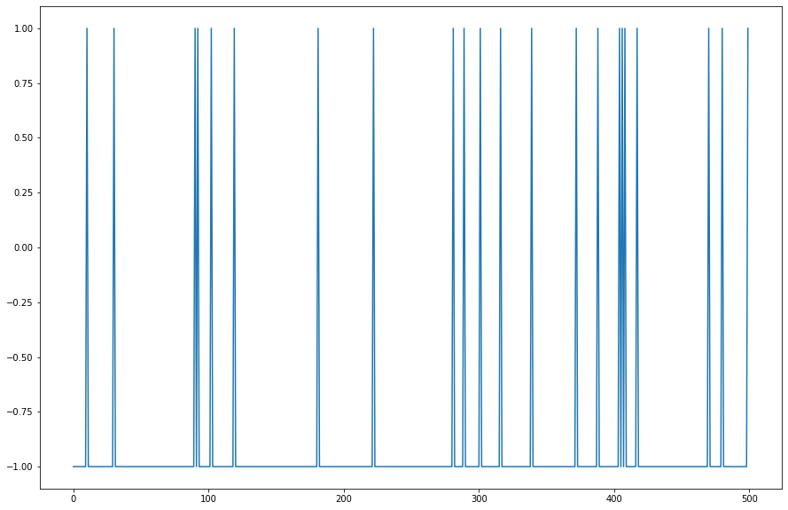

```python
plt.figure(figsize=(15, 10))
plt.plot(ypocket[:500])
```

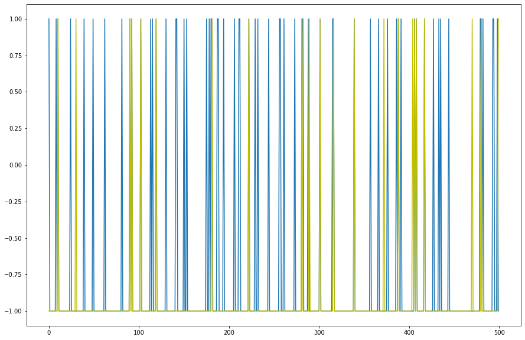

```python
plt.figure(figsize=(15, 10))
plt.plot(y_test[:500])
plt.plot(ypocket[:500] ,color = 'y')
plt.show()
```

#### Plots for QDA

```python
obj = QDA()
obj.train(X_train,y_train)
y_qda=obj.use(X_test)
y_qda
```

```
(8238, 2)
[1 1 1 ... 1 1 1]
[0 1]
[-1  1]
```

```
array([-1, -1, -1, ..., -1, -1, -1])
```

```python
plt.figure(figsize=(15, 10))
plt.plot(y_test[:500], label='Y_test')
```

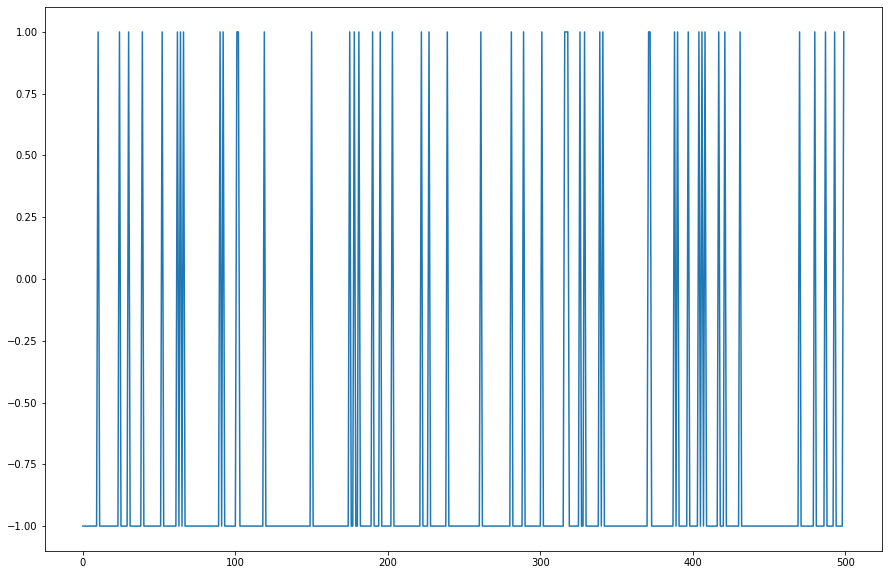

```python
plt.figure(figsize=(15, 10))
plt.plot(y_qda[:500])
```

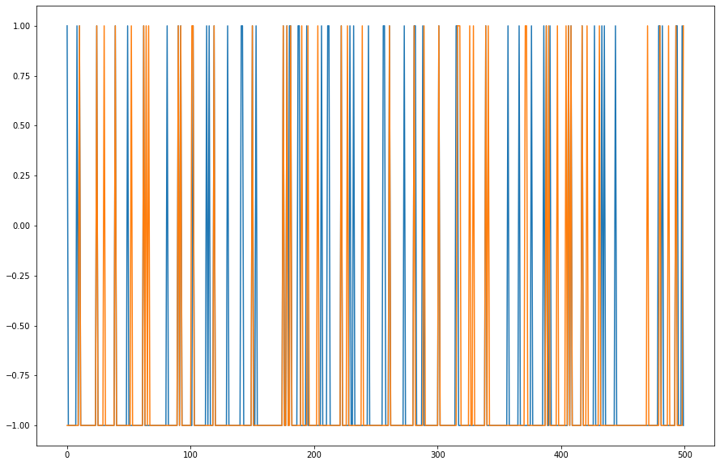

```python
plt.figure(figsize=(15, 10))
plt.plot(y_test[:500])
plt.plot(y_qda[:500])
```

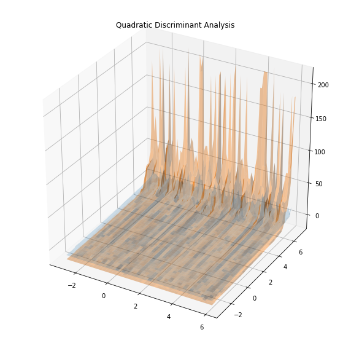

```python
from mpl_toolkits.mplot3d import Axes3D
xs, ys = np.meshgrid(np.linspace(-3,6, 90), np.linspace(-3,7, 90))
fig = plt.figure(figsize=(10,10))
pq = fig.gca(projection='3d')
pq.plot_surface(xs, ys, np.sort(-1 *obj.n1[:8100].reshape(xs.shape),0), alpha=0.2)
pq.plot_surface(xs, ys, np.sort(-1 *obj.n2[:8100].reshape(xs.shape),0), alpha=0.4)
plt.title("Quadratic Discriminant Analysis")
```

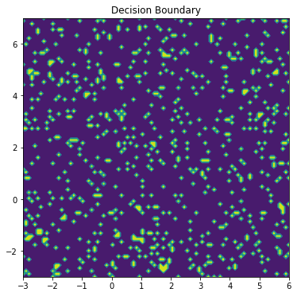

```python
plt.figure(figsize=(6,6))
plt.contourf(xs, ys, (obj.n1[:8100]-obj.n2[:8100] > 0).reshape(xs.shape))
plt.title("Decision Boundary")
```

#### Plots for LDA

```python
obj1 = LDA()
obj1.train(X_train,y_train)
y_lda=obj1.use(X_test)
(y_lda)
```

```
(8238, 2)
[1 1 1 ... 1 1 1]
[1]
[-1]
[[-38.27633449  -1.98171208]
 [-37.27499753  -2.10918736]
 [-38.87575163  -1.90540324]
 ...
 [-36.7132759   -2.18069737]
 [-38.07711218  -2.00707409]
 [-36.50687929  -2.20697271]]
```

```
array([-1, -1, -1, ..., -1, -1, -1])
```

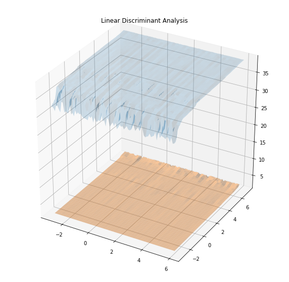

```python
xs, ys = np.meshgrid(np.linspace(-3,6, 90), np.linspace(-3,7, 90))
fig = plt.figure(figsize=(10,10))
pq = fig.gca(projection='3d')
pq.plot_surface(xs, ys, np.sort(-1 *lda.n1[:8100].reshape(xs.shape),0), alpha=0.2)
pq.plot_surface(xs, ys, np.sort(-1 *lda.n2[:8100].reshape(xs.shape),0), alpha=0.4)
plt.title("Linear Discriminant Analysis")
```

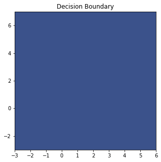

```python
plt.figure(figsize=(5,5))
plt.contourf(xs, ys, (lda.n1[:8100]-lda.n2[:8100] > 0).reshape(xs.shape))
plt.title("Decision Boundary")
```

#### Plots for Logistic Regression

```python
lr= LogisiticRegression(1000,0.0001)
#adding zeros
y_Test = np.zeros((X_train.shape[0], 2))
#print(y_Test)
y_Test[:,0] = y_train == -1
y_Test[:,1] = y_train == 1
lr.train(X_train,y_Test)
y_pred_log=lr.use(X_test)
#y_pred_log
#np.sum(y_pred_log==1)
```

```
[[ 0.14006677  0.84214341]
 [ 1.02822807  0.27661103]
 [ 1.02963755  0.60257233]
 [ 0.06063982  0.58884917]
 [ 0.91032591  0.53984672]
 [ 0.43891047  1.04970465]
 [ 0.59291388  0.9965904 ]
 [ 0.24235615  0.78556409]
 [ 0.02509705  1.05950067]
 [-0.15131707  0.75638593]
 [ 0.61538786  0.99057518]
 [-0.07667899  1.03403848]
 [ 0.45675436  1.20882573]
 [ 0.39132494  0.31178204]
 [ 0.60622399  0.73535811]
 [ 1.30756792  0.05726539]
 [ 0.64746091 -0.10482809]
 [-0.69159641  1.65272313]]
```

```python
plt.figure(figsize=(15, 10))
plt.plot(y_test[:500])
```

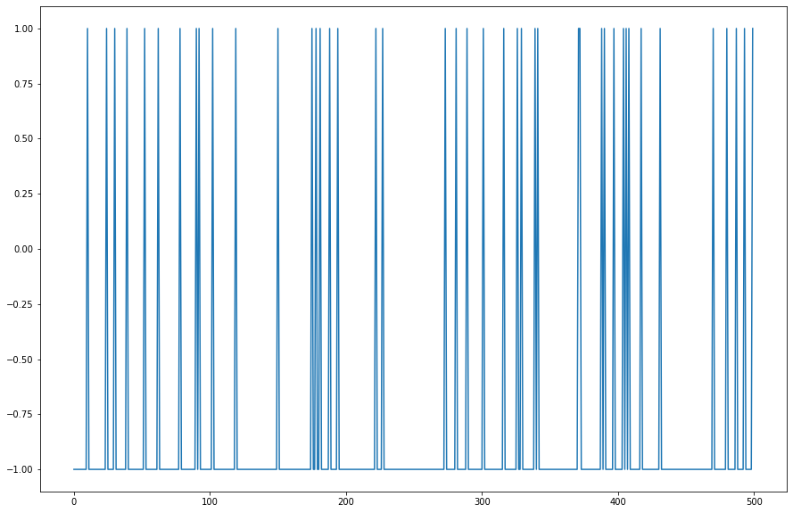

```python
plt.figure(figsize=(15, 10))
plt.plot(y_pred_log[:500])
```

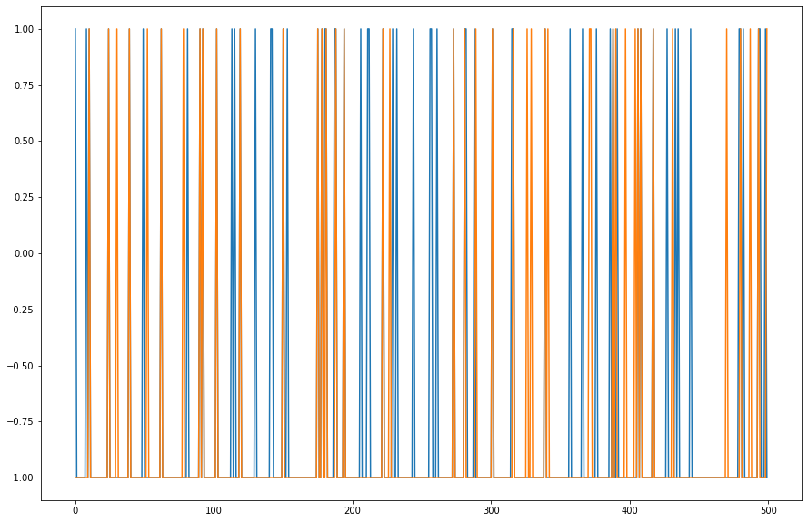

```python
plt.figure(figsize=(15, 10))
plt.plot(y_test[:500])
plt.plot(y_pred_log[:500])
# blue = actual
# orange = predicted
```

## Evaluation Metrics and Accuracies for Algorithms

# Measurements

How to evaluate a machine learning model is critical for the choice of right tools and performance. For various reason, there are several classification measurements to meet different needs for practical applications. In this section, we examine popular measures.

One naive evaluation we can think of is the rate or percentage or correct classification. That is, when there are 1000 target lables to classify, if 950 are correctly classified, we can say 95% accuracy:

$$ \text{Accuracy} = \frac{\text{The number of correct classification}}{\text{The number of samples}}. $$

This measure, however, can be uninformative, especially when the importance of each class is different. As in our previous discussion about imbalance of data samples, sometimes we need to care more a specific class. For this, confusion matrix lists all the counts for all classes.

## Confusion Matrix

Here is an example confusion matrix.

|  | - | + |
| --- | --- | --- |
| - | 439 | 28 |
| + | 22 | 511 |

Table 1. Example Confusion Matrix

Here, each row represents the predictions from model and column represents the actual classes. So, we can read this that for negative samples, 439 samples are correctly classified while 511 samples are correctly classified for positive data. Overall the accuracy is 95% but with confusion matrix we have more information about the classification results.

Here follows the short implementation of confusion matrix.

#### Confusion matrix

```python
def confusion_matrix(Y, T):
    """
        Y    ndarray
             predicted labels
        T    ndarray
             target labels

        @cfm DataFrame
             confusion matrix
    """

    if len(Y) != len(T):
        raise ValueError("Wrong prediction and target length!")

    classes = np.unique(T)
    n_classes = len(classes)

    cfm = pd.DataFrame(np.zeros((n_classes, n_classes)), index=classes, columns=classes, dtype=int)

    Tidx = [T == c for c in classes]
    for c in classes:
        pred_idx = Y == c
        cfm.loc[c, :] = [np.sum(np.logical_and(pred_idx, tidx)) for tidx in Tidx]

    return cfm
```

```
      -1.0   1.0
-1.0  7255    64
 1.0   762   157
```

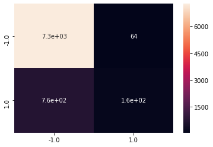

```python
#Pocket
cfm=confusion_matrix(y_test, ypocket)
ax= plt.subplot()
sns.heatmap(cfm, annot=True, ax = ax);
print(cfm)
```

```
      -1    1
-1  6912  407
 1   583  336
```

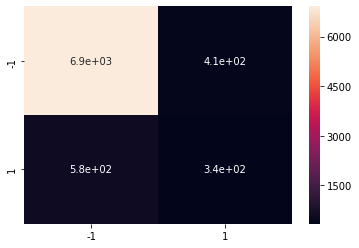

```python
#QDA
cfm=confusion_matrix(y_test, y_qda)
ax= plt.subplot()
sns.heatmap(cfm, annot=True, ax = ax);
print(cfm)
```

```
      -1
-1  7319
```

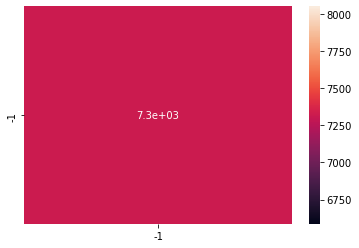

```python
#LDA
cfm=confusion_matrix(y_test, y_lda)
ax= plt.subplot()
sns.heatmap(cfm, annot=True, ax = ax);
print(cfm)
```

```
      -1    1
-1  6952  367
 1   593  326
```

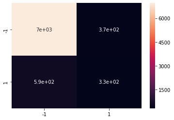

```python
#Logistic Regression
cfm=confusion_matrix(y_test, y_pred_log)
ax= plt.subplot()
sns.heatmap(cfm, annot=True, ax = ax);
print(cfm)
```

### F1

```python
from sklearn.metrics import f1_score
def f1score(actual,predicted):
    return f1_score(actual,predicted)
```

```python
x = f1_score(y_test,ypocket)
print("Pocket F1 score:", x)
```

```
Pocket F1 score: 0.2754385964912281
```

```python
x = f1_score(y_test,y_qda)
print("QDA F1 score:", x)
```

```
QDA F1 score: 0.4043321299638989
```

```python
x = f1_score(y_test,y_lda)
print("LDA F1 score:", x)
```

```
LDA F1 score: 0.0
```

```python
x = f1_score(y_test,y_pred_log)
print("Logistic F1 score:", x)
```

```
Logistic F1 score: 0.40446650124069483
```

### Accuracy

```python
def accuracy(actual,predicted):
    return (np.sum(actual==predicted))/predicted.shape[0]
```

```python
x = accuracy(y_test,ypocket)
print("Pocket Accuracy:", x)
```

```
Pocket Accuracy: 0.8997329448895363
```

```python
x = accuracy(y_test,y_qda)
print("QDA Accuracy:", x)
```

```
QDA Accuracy: 0.8798252002913328
```

```python
x = accuracy(y_test,y_lda)
print("LDA Accuracy:", x)
```

```
LDA Accuracy: 0.888443797038116
```

```python
x = accuracy(y_test,y_pred_log)
print("LR Accuracy:", x)
```

```
LR Accuracy: 0.8834668608885652
```

```python
def precision(actual,predicted):
    return (np.sum(actual==predicted))/predicted.shape[0]
```

```python
x = precision(y_test,ypocket)
print("Pocket Precision:", x)
```

[output not shown]

```python
x = precision(y_test,y_lda)
print("LDA Precision:", x)
```

[output not shown]

```python
x = precision(y_test,y_qda)
print("QDA Precision:", x)
```

[output not shown]

```python
x = precision(y_test,y_pred_log)
print("Logistic Regression Precision:", x)
```

[output not shown]

### Sensitivity Recall

```python
from sklearn.metrics import recall_score
def recallscore(actual,predicted):
    return recall_score(actual,predicted)
```

```python
x = recall_score(y_test,ypocket)
print("Pocket Recall:", x)
```

```
Pocket Recall: 0.1708378672470076
```

```python
x = recall_score(y_test,y_qda)
print("QDA Recall:", x)
```

```
QDA Recall: 0.36561479869423286
```

```python
x = recall_score(y_test,y_lda)
print("LDA Recall:", x)
```

```
LDA Recall: 0.0
```

```python
x = recall_score(y_test,y_pred_log)
print("Logistic Regression Recall:", x)
```

```
Logistic Regression Recall: 0.35473340587595215
```

### Precision Recall Curve

```
Average precision-recall score: 0.21
```

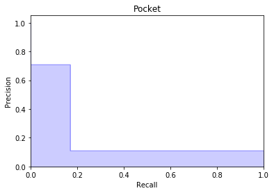

```python
from sklearn.metrics import precision_recall_curve
import matplotlib.pyplot as plt
from sklearn.metrics import average_precision_score
from inspect import signature

precision, recall, _ = precision_recall_curve(y_test, ypocket)

# In matplotlib < 1.5, plt.fill_between does not have a 'step' argument
step_kwargs = ({'step': 'post'}
               if 'step' in signature(plt.fill_between).parameters
               else {})
plt.step(recall, precision, color='b', alpha=0.2,
         where='post')
plt.fill_between(recall, precision, alpha=0.2, color='b', **step_kwargs)
plt.title('Pocket')
plt.xlabel('Recall')
plt.ylabel('Precision')
plt.ylim([0.0, 1.05])
plt.xlim([0.0, 1.0])

average_precision = average_precision_score(y_test, ypocket)

print('Average precision-recall score: {0:0.2f}'.format(
      average_precision))
```

```
Average precision-recall score: 0.24
```

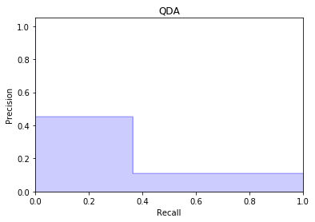

```python
precision, recall, _ = precision_recall_curve(y_test, y_qda)

# In matplotlib < 1.5, plt.fill_between does not have a 'step' argument
step_kwargs = ({'step': 'post'}
               if 'step' in signature(plt.fill_between).parameters
               else {})
plt.step(recall, precision, color='b', alpha=0.2,
         where='post')
plt.fill_between(recall, precision, alpha=0.2, color='b', **step_kwargs)
plt.title('QDA')
plt.xlabel('Recall')
plt.ylabel('Precision')
plt.ylim([0.0, 1.05])
plt.xlim([0.0, 1.0])
average_precision = average_precision_score(y_test, y_qda)
print('Average precision-recall score: {0:0.2f}'.format(
      average_precision))
```

```
Average precision-recall score: 0.11
```

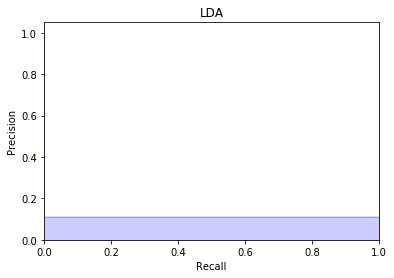

```python
precision, recall, _ = precision_recall_curve(y_test, y_lda)

# In matplotlib < 1.5, plt.fill_between does not have a 'step' argument
step_kwargs = ({'step': 'post'}
               if 'step' in signature(plt.fill_between).parameters
               else {})
plt.step(recall, precision, color='b', alpha=0.2,
         where='post')
plt.fill_between(recall, precision, alpha=0.2, color='b', **step_kwargs)
plt.title('LDA')
plt.xlabel('Recall')
plt.ylabel('Precision')
plt.ylim([0.0, 1.05])
plt.xlim([0.0, 1.0])
average_precision = average_precision_score(y_test, y_lda)

print('Average precision-recall score: {0:0.2f}'.format(
      average_precision))
```

```
Average precision-recall score: 0.24
```

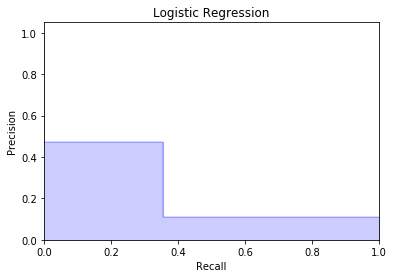

```python
precision, recall, _ = precision_recall_curve(y_test, y_pred_log)

# In matplotlib < 1.5, plt.fill_between does not have a 'step' argument
step_kwargs = ({'step': 'post'}
               if 'step' in signature(plt.fill_between).parameters
               else {})
plt.step(recall, precision, color='b', alpha=0.2,
         where='post')
plt.fill_between(recall, precision, alpha=0.2, color='b', **step_kwargs)
plt.title('Logistic Regression')
plt.xlabel('Recall')
plt.ylabel('Precision')
plt.ylim([0.0, 1.05])
plt.xlim([0.0, 1.0])
average_precision = average_precision_score(y_test, y_pred_log)

print('Average precision-recall score: {0:0.2f}'.format(
      average_precision))
```

## Classification model comparison

1.Pocket : 0.27,0.21

2.QDA : 0.4043,0.24

3.LDA : 0.0,0.11

As Pocket is a perceptron learning technique it takes a lot of time to run and compute the result compared to QDA,LDA and Logistic Regression.

## Conclusion

- Challenges: I initially struggled with the pocket algorithm for choosing right set of columns after one hot encoding as if wrong columns were selected then the algorithm was giving different errors.

## References

1. "Precision-Recall — scikit-learn 0.21.3 documentation." Scikit-learn: machine learning in Python — scikit-learn 0.16.1 documentation. Web. http://scikit-learn.org/stable/auto_examples/model_selection/plot_precision_recall.html
2. Kaggle.com. (2019). Bank Marketing. [online] Available at: https://www.kaggle.com/henriqueyamahata/bank-marketing [Accessed 16 Oct. 2019].
3. Nbviewer.jupyter.org. (2019). Jupyter Notebook Viewer. [online] Available at: https://nbviewer.jupyter.org/url/webpages.uncc.edu/mlee173/teach/itcs6156/notebooks/notes/Note-Classification.ipynb [Accessed 16 Oct. 2019].
4. Nbviewer.jupyter.org. (2019). Jupyter Notebook Viewer. [online] Available at: https://nbviewer.jupyter.org/url/webpages.uncc.edu/mlee173/teach/itcs6156/notebooks/notes/Note-Linear%20Classification.ipynb [Accessed 16 Oct. 2019].
5. Anon, (2019). [online] Available at: https://www.semanticscholar.org/paper/Is-Pocket-algorithm-optimal-Muselli/a8c52c [Accessed 16 Oct. 2019].
6. En.wikipedia.org. (2019). Perceptron. [online] Available at: https://en.wikipedia.org/wiki/Perceptron [Accessed 16 Oct. 2019].
7. En.wikipedia.org. (2019). Quadratic classifier. [online] Available at: https://en.wikipedia.org/wiki/Quadratic_classifier [Accessed 16 Oct. 2019].
8. En.wikipedia.org. (2019). Latent Dirichlet allocation. [online] Available at: https://en.wikipedia.org/wiki/Latent_Dirichlet_allocation [Accessed 16 Oct. 2019].
9. Brownlee, J. (2019). Logistic Regression for Machine Learning. [online] Machine Learning Mastery. Available at: https://machinelearningmastery.com/logistic-regression-for-machine-learning/ [Accessed 16 Oct. 2019].